# Starbucks Geocoding Demo

Andy Grogan-Kaylor

2020-11-05

# Background

*geocoding* is the process of **turning addresses into latitudes and longitudes** that can then be read into GIS or mapping software.

- In *ArcGIS*, proprietary GIS software, geocoding is a built in function, albeit one depending on access to a separate licensed database. This may be the best choice for especially sensitive data.
- With *open source software* solutions are constantly changing, and depend on *some creativity*.
- As always with all data, and perhaps especially with *GIS data*, one needs to think carefully about respondent confidentiality.

> **Does sharing a respondent’s address with a geocoding server potentially compromise a respondent’s safety or security?**

# Workflow

[interactive chart not shown]

# Web Solution (limit 250 addresses)

[batchgeo.com](https://batchgeo.com/) is one of several websites that will geocode addresses.

**batchgeo.com** has a limit of **250** addresses.

Geocoded data can be saved as *KML*, Google Earth’s format, which can then be read into QGIS: http://support.batchgeo.com/customer/en/portal/articles/1457646-exporting-map-data

[figure not shown]

screenshot of batchgeo.com

# Data Wrangling

## Concatenate Addresses

Address processing across GIS is constantly evolving.

- The *old standard* still used in *ArcGIS* was that you needed *separate fields* for *street address*, *city*, *state* and *ZIP*
- The *new standard* is that all of these fields should be merged together, though separated by commas.

> **Do your addresses need to be concatenated?** **Do your addresses need to be separated?**

# Simple Map in R

```r
load("geocoded_Starbucks.Rdata")
```

Here is what this data looks like:

Table continues below

| lon | lat | type | loctype | address |
| --- | --- | --- | --- | --- |
| -84.03 | 41.88 | street_address | rooftop | 1515 E. US 223, Adrian, MI, US |
| -83.2 | 42.28 | street_address | rooftop | 23005 Outer Drive, Allen Park, MI, US |
| -83.2 | 42.3 | street_address | rooftop | 3100 Fairlane Dr, Allen Park, MI, US |
| -85.89 | 42.96 | street_address | rooftop | 1 Campus Dr, Allendale, MI, US |
| -85.94 | 42.97 | street_address | rooftop | 6370 Lake Michigan Dr Ste 100, Allendale, MI, US |
| -84.67 | 43.38 | street_address | rooftop | 328 W Superior St, Alma, MI, US |

Table continues below

| north | south | east | west | street_number | route |
| --- | --- | --- | --- | --- | --- |
| 41.88 | 41.87 | -84.03 | -84.03 | 1515 | US Hwy 223 |
| 42.28 | 42.27 | -83.2 | -83.2 | 23701 | Outer Dr |
| 42.3 | 42.29 | -83.19 | -83.2 | 2998 | Fairlane Dr |
| 42.97 | 42.96 | -85.89 | -85.89 | 1 | N Campus Dr |
| 42.97 | 42.97 | -85.94 | -85.94 | 6370 | Lake Michigan Dr |
| 43.38 | 43.38 | -84.66 | -84.67 | 328 | W Superior St |

| locality | administrative_area_level_1 | country |
| --- | --- | --- |
| Adrian | MI | United States |
| Allen Park | MI | United States |
| Allen Park | MI | United States |
| Allendale | MI | United States |
| Allendale | MI | United States |
| Alma | MI | United States |

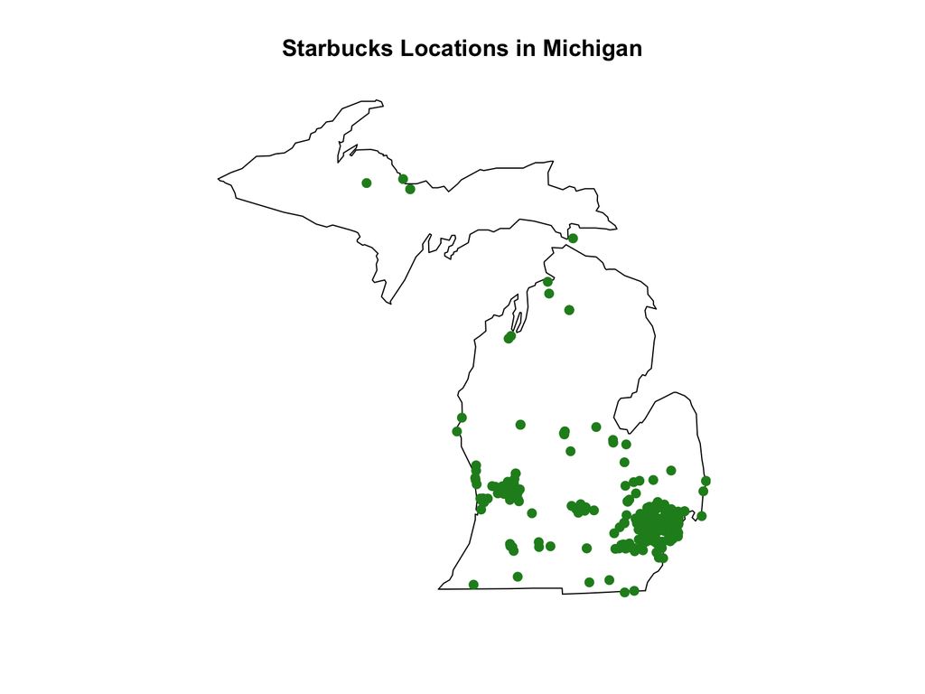

Map Using library(maps)

```r
library(maps)

map("state",
    regions = "michigan")

# base R for adding points to pre-existing graph

points(geocoded_Starbucks$lon,
       geocoded_Starbucks$lat,
       pch = 19, # Point CHaracter
       col = "forestgreen")

title("Starbucks Locations in Michigan")
```

# QGIS Map

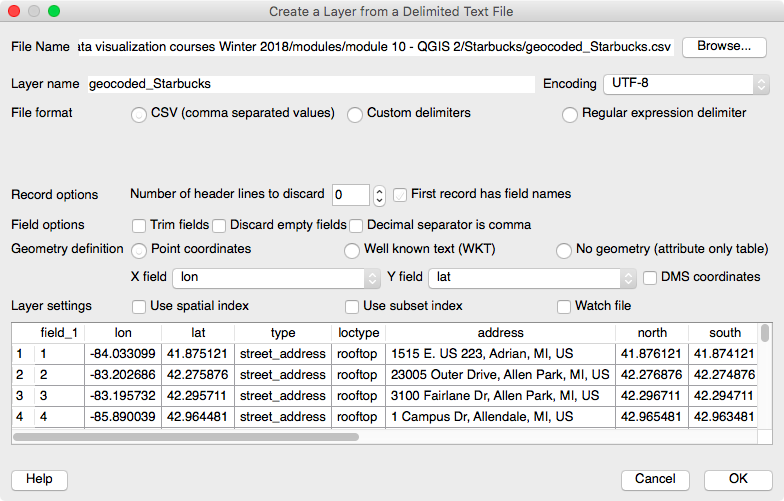

Importing Delimited Text with X and Y Coordinates

[figure not shown]

QGIS Map of Starbucks in Michigan